# 面向对象编程

王一帆

江苏企业大学

# 什么是面向对象编程

请思考这样一个问题:A让B去打印文件.A如何做?B如何做?

- 面向对象关心和处理的是对象的应用和组合
- 在面向对象的语言中,对象的概念一定是一等的.对象可以被存储,传递还有返回,和语言中的其它数据一样.
- 面向对象编程将应用领域定义为一组名词及其之间的交互.

# 类与对象

- 类是对一个特定类型对象的描述(人类,鸟类),它定义了一种新的类型
- 类定义中的成员变量可以是任意类型(基本类型,数组,类)
- 对象是类的实体

# 类之间的关系

- is (like) a
- has a

# 继承(泛化)

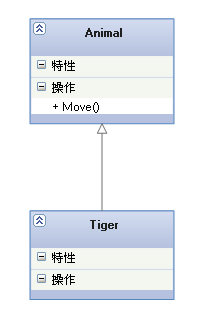

# 实现

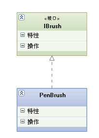

# 组合

在逻辑上A是B的“一部分”（a part of），需要用A和其它东西组合出B。A和B不可分,比如人和大脑

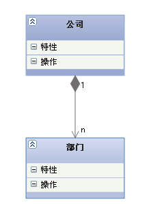

# 聚合

A和B可分.比如电脑和CPU

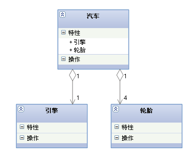

# 关联

是一种拥有的关系,它使一个类知道另一个类的属性和方法

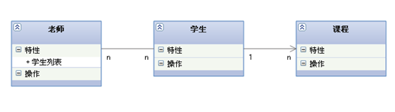

# 依赖

一个类依赖于另一个类的定义.比如方法参数,局部变量,静态方法调用.

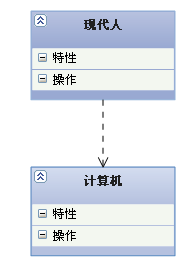

# Java与面向对象

- 除了基本类型(有包装类),Java中一切都是对象
- Java使用引用来操作对象

# 定义类

- 定义一个圆
- 包含属性半径
- 包含计算周长和面积的方法

# Hello.java

先来看Hello.java程序,回忆一下它由哪几部分组成?

```java
public class Hello{
    public static void main(String[] args){
        System.out.println("Hello");
    }
}
```

```java
public class Circle{
    public double radius;

    public double perimeter(){
         double l = 2 * 3.14 * radius;
         return l;
    }

    public double area(){
         double a = 3.14 * radius * radius;
         return a;
    }
}
```

# 类的定义

```
[权限控制符] class关键字 类名 {
    [成员变量]
    [方法]
}
```

```java
public class Circle{
    ...
}
```

# 成员变量定义

```
[权限控制符] [其它修饰符] 类型 变量名称 [赋值语句] ;
```

```java
public double radius;
```

# 方法定义

```
[权限控制符] [其它修饰符] 返回值类型 方法名称 ([参数列表]) {
    [方法体]
}
```

```java
public double perimeter(){
     double l = 2 * 3.14 * radius;
     return l;
}
```

- 方法名和参数列表可以唯一的确定一个方法

# 参数列表

```java
public class Test{
    public void p(int a){
        System.out.println(a);
    }

    public static void main(String[] args){
        Test test = new Test();
        test.p(2);
        test.p(3);
    }
}
```

# 可变参数列表

```java
public class Test{
    public void p(int... a){
        for(int i = 0; i < a.length; i++){
            System.out.println(a[i] + " ");     //看出来a是什么类型了吗?
        }
    }

    public static void main(String[] args){
        Test test = new Test();
        test.p(2,2,3);
        test.p(3,4,5,6,7);
    }
}
```

- 变长参数一定要是最后一个参数

# 课堂练习

- 新建矩形类Rect,
- 包含长度和宽度
- 以及计算周长和面积的方法

# 答案

```java
public class Rect{
    public double width;
    public double height;

    public double perimeter(){
        return 2 * (width + height);
    }

    public double area(){
        return width * height;
    }
}
```

# 创建对象

- 请回忆数组的创建过程!

```java
...
int[] arr = {1,2,3};
int[] arr = new int[3];  //默认初始化
...
```

```java
Circle circle = new Circle();
```

# 简单模型

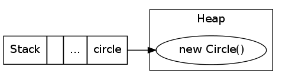

# 使用引用操作对象

- Java使用 . 操作符来访问属性和方法

```java
public static void main(String[] args){
    Circle circle = new Circle();
    circle.radius = 3;
    System.out.println(circle.perimeter());
    circle.radius = 4;
    System.out.println(circle.perimeter());
}
```

# 访问控制符

- public:对所有的类和对象都是可见的
- private:只对类内部是可见的
- default(friend,package):对包内部是可见的(相当于public),对包外部是不可见的(相当于private)
- protected:只对类内部和子类是可见的

# 规范

- 对于属性来说,一般是private的(对象与对象之间通过传递消息来通信,也就是方 法调用)
- 如果需要访问属性,则提供getter和setter方法来获取或设置属性
- 如果方法只提供给类内部使用,则设置为private
- 如果方法值提供给子类使用或覆写,则设置为protected
- 如果类只给包里的类使用,则设置为default

# 例子

- 按规范修改Circle的访问控制

```java
public class Circle{
    private double radius;

    ....

    public double getRadius(){return radius;}
    public void setRadius(double radius){this.radius = radius;}

}
```

- 调用

```java
public static void main(String[] args){
    Circle circle = new Circle();
    circle.setRadius(3);
    System.out.println(circle.perimeter());
}
```

# 课堂练习

- 修改矩形类,限制属性的访问权限
- 提供属性的访问方法

# 答案

```java
public class Rect{
    private double width;
    private double height;

    public Rect(double width,double height){
        this.width = this.width;
        this.height = this.height;
    }

    public double perimeter(){
        return 2 * (width + height);
    }

    public double area(){
        return width * height;
    }

    public double getWidth(){return width;}
    public double setWidth(double width){this.width = width;}
    public double getHeight(){return height;}
    public double setHeight(double height){this.height = height;}
}
```

# 构造方法

```java
Circle circle = new Circle();
```

做了什么?

# 默认构造方法

- Java中每个类都有一个无参的默认构造方法
- 如果手动添加了构造方法,则Java不会添加默认构造方法

```java
public class Circle{
    public Circle(){}
}
```

# 自定义构造方法

```java
public class Circle{
    public Circle(int r){
        radius = r;
    }
}
```

```java
Circle circle = new Circle();  //试试还能编译成功吗?
```

- 需要r吗?
- 可以使用radius吗?

# 这样?

```java
public class Circle{
    public Circle(int radius){
        radius = radius;   //有问题吗?
    }
}
```

# 作用范围

- 成员变量作用范围:在类范围内
- 方法参数作用范围:在方法内部
- 局部变量作用范围:在声明变量的语句块内部
- 作用范围覆盖

# 例子

```java
public class Test{
    private int a = 1;
    private int b = 1;
    public void f(int a){
        p();
        System.out.println(a);
        int a = 3;      //可以吗?
        int b = 4;
        System.out.println(b);
    }

    public void p(){
        System.out.println(a);
    }

    public static void main(String[] args){
        new Test().f(2);
    }
}
```

# 解决方案

```java
public class Circle{
    public Circle(int radius){
        radius = radius;      //变量覆盖
    }
}
```

- Java提供了this关键字
- 它是指向自身的引用

```java
public class Circle{
    ...
    public Circle(int radius){
        this.radius = radius;
    }
}
```

# static

- static标示的属性或方法,是类属性或方法
- static标示的属性或方法直接使用类来调用
- 非static标示的属性或方法,是对象属性或方法
- 在非静态方法中可以访问静态方法吗?
- 在静态方法中可以调用非静态方法吗?
- 可以使用this来调用静态方法或静态属性吗?

# 示例

```java
public class Test{
    static int a;
    public static void p(int a){
        System.out.println(a);
        s();   //OK?
    }
    public void s(){
        p(1);   //OK?
    }

    public static void main(String[] args){
        Test.a = 3;
        Test.p(2);
        Test.s();    //OK?
        Test test = new Test();
        test.s();
        test.p(5);    //OK?
    }
}
```

# 构造方法之外

- 初始化块
- 静态初始化块

# 初始化块

- Java类内部一段{}包裹的代码,负责初始化对象属性
- 初始化块在构造方法之前执行

```java
public class Test{
    int a;
    static int b;
    {
        a = 3;  //OK?
        b = 3;  //OK?
    }
}
```

# 静态初始化块

- Java类内部一段static{}包裹的代码,负责初始化静态属性
- 静态初始化块只在类加载时执行一次

```java
public class Test{
    int a;
    static int b;
    static {
              a = 3;  //OK?
              b = 3;  //OK?
           }
}
```

# 初始化顺序

- 变量需要先赋值才能使用!

```java
public class Circle {

    int radius = prt("初始化radius");
    int t = prt("初始化t");
    static int s = prt("初始化s");

    {System.out.println("初始化块");}

    static{
        System.out.println("静态初始化块");
    }

    public Circle(){
        System.out.println("默认构造方法");
    }

    public static int prt(String text){
        System.out.println(text);
        return 0;
    }

    public static void main(String[] args){
        Circle circle = new Circle();
        Circle circle2 = new Circle();
    }
}
```

# 清理

- 不需要手动清理对象
- Java提供垃圾回收机制
- 不可靠的finalize()

# 管理对象

我们现在有Circle,Rect类,以及调用类,如果还要添加其它的类.势必导致当前目 录下的类越来越多,难以管理!如何处理这样的问题?

# 包

- 包管理相同类型的类
- 使用package关键字
- .java文件需要放到与包名对应的目录下

# 例子

```java
package com.learn.shape;
public class Circle{ ... }
```

# 引入

- 使用import关键字引入类
- 引入整个包
- 静态引入

# 例子

```java
import com.learn.shape.*;

import com.learn.shape.Circle;
import com.learn.shape.Rect;

import static com.learn.shape.Circle.*;
```

# 默认访问控制

- 默认访问控制对包内的类是public的,对包外的类是private的

```java
package test;
class A{}
```

```java
import test.A;
class Test{
    public static void main(String[] args){
        A a = new A();   //OK?
    }
}
```

```java
package test;
class Test{
    public static void main(String[] args){
        A a = new A();   //OK?
    }
}
```

# classpath进阶

- 如何查询包里的类

```java
javac path/*.java
java package.ClassName
```

# 使用eclipse

- 将Circle,Rect类导入到eclipses中

# 深入方法调用

- 打印Circle的面积

```java
public class Test{
    public static void main(String[] args){
        Test test = new Test();
        int num = 10;
        test.showInt(num);
        Circle circle = new Circle();
        test.showArea(circle);
    }

    public void showInt(int num){
        System.out.println(num);
    }

    public void showArea(Circle circle){
        System.out.println(circle.area());
    }
}
```

# 简化模型

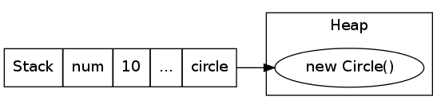

# 传值还是传引用?

```java
public class Test{
    public static void main(String[] args){
        Test test = new Test();
        int num = 10;
        test.showInt(num);
        System.out.println("num = " + num);
        Circle circle = new Circle();
        test.showArea(circle);
        System.out.println("outer area :" + circle.area());
    }

    public void showInt(int num){
        num = 20;
        System.out.println("inner num = " + num);
    }

    public void showArea(Circle circle){
        circle.radius = 5;
        System.out.println("inner area :" + circle.area());
    }
}
```

# 课堂练习

- 打印Rect的面积

```java
public class Test{
    ...

    public void showArea(Circle circle){
        System.out.println(circle.area());
    }

    public void showArea2(Rect rect){
        System.out.println(rect.area());
    }
}
```

- 方法名可以相同吗?

# 方法重载

- 方法名和参数列表可以唯一的确定一个方法
- 在同一个类中,方法名相同,参数列表不同称为方法重载
- 思考前面我们是否使用了方法重载?

# 重复代码

```java
public class Test{
    ...

    public void showArea(Circle circle){
        System.out.println(circle.area());
    }

    public void showArea(Rect rect){
        System.out.println(rect.area());
    }
}
```

- 两个showArea方法代码基本相同,除了参数及参数的方法调用
- Circle和Rect功能相同,实现不同
- 如果我还有其它类,比如三角形类,是否还需要再添加一个showArea方法来处理?
- showArea方法是否可以统一处理?

# 继承

- 在一个现有类的基础上定义新的类,称为派生或继承
- 新生成的类称为派生类
- 原始的类称为基类
- 派生类又称为基类的子类,基类又称为派生类的父类
- 派生类还可以作为基类,去派生其它类
- Java中的类都默认继承Object

# 代码重构

```java
public class Circle{
    public double preimeter(){...}
    public doible area(){...}
}
public class Rect{
    public double preimeter(){...}
    public doible area(){...}
}
```

# 父类

```java
public class Shape{
    public double area(){return 0;}
}
```

# 继承

```java
public class Circle extends Shape{...}
public class Rect extends Shape{...}
```

# 方法重写

- 子类覆盖父类的方法,称为方法重写
- JDK5之后,提供@Override,来确保子类正确的覆盖了父类的方法
- 子类不可降低父类的访问权限
- 子类不可提升父类抛出的异常

# 课堂练习

- 在父类中添加perimeter方法,并在Circle和Rect中覆写此方法
- 修改子类的area方法的访问控制符,查看IDE信息
- 在Circle和Rect添加字符串属性color及setter和getter方法

# 如何在子类访问父类被重写的方法?

- 如果我就想访问父类的方法呢?
- 比如在Circle的area方法中打印Shape的area返回值!如何处理?

```java
public class Circle{
    public double area(){
       ...
       area();             //OK?
    }
}
```

- super关键字

# 代码复用

- Circle与Rect中的color相关代码完全相同

```java
public class Circle{
    private String color;
    getter()
    setter()
}
public class Rect{
    private String color;
    getter()
    setter()
}
```

- Do not repeat yourself!
- 重构!提升代码到父类中!(使用eclipse)

# 子类访问父类属性和方法

- 子类可以直接访问父类的非private的方法和属性,就像访问自己内部的方法和属性一样

```java
public class Shape{
    private String color;
    public void setColor(String color){this.color = color;}
    public String getColor(){return color;}
}
```

```java
Circle c = new Circle();
c.color;            //OK?
c.getColor();      //OK?
```

# 再论初始化顺序

```java
public class Shape{
    public Shape(){System.out.println("Shape构造方法");}
}

public class Circle extends Shape {

    public Circle(){
        System.out.println("Circle构造方法");
    }

    public static void main(String[] args){
        Circle circle = new Circle();
    }
}
```

# 多态

# 向上转型

- 子类is (like) a父类
- 父类引用指向子类对象

```java
Shape s = new Circle();   //OK?
s.getColor();      //OK?
s.getRadius();    //OK?
```

# 向下转型

```java
Shape s = new Circle();   //OK?
s.getColor();      //OK?
((Circle)s).getRadius();    //OK?
```

# 重构showArea

```java
public class Test{
    ...

    public void showArea(Rect rect){
        System.out.println(rect.area());
    }

    public void showArea(Circle circle){
        System.out.println(circle.area());
    }
}
```

```java
public class Test{
    public static void main(String[] args){
        Circle c = new Circle(2);
        showArea(c);
        Rect r = new Rect(2,3);
        showArea(r);
    }

    public void showArea(Shape shape){
        System.out.println(shape.area());
    }
}
```

# 动态绑定

- Java采用动态绑定(后期绑定)
- 在方法运行时才确认具体的内容
- 具体类型的确认是依据new后面的类型来确认
- 抽象类
- Shape中的area和perimeter方法需要实现吗?

```java
public class Shape{
    public double area(){return 0;}
    public double perimeter(){return 0;}
}
```

# 抽象方法

- 使用abstract修饰的方法称为抽象方法.抽象方法没有方法体
- 包含抽象方法的类称为抽象类.抽象类也需要使用abstract来修饰
- 抽象类可以不包括抽象方法

```java
public abstract class Shape{
    ...
    public abstract double area();
    public abstract double perimeter();
}
```

# 接口

- 如果抽象类中的方法全部都是抽象方法,那么可以将抽象类定义为接口

# Java8之前

- 接口中的成员变量全部为public static final
- 接口中的方法全部为public abstract

```java
public interface Shape{
    double area();
    double perimeter();
}
public class Circle implements Shape{...}
public class Rect implements Shape{...}
```

- 可以实现多个接口,以逗号隔开

# Java8

- 可以有默认方法

# final关键字

- 一个永不改变的编译时常量(哪里不变?)
- 一个在运行时被初始化的值,而你不希望它被改变
- private方法默认是final的
- final类不能被继承

```java
public class Test{
    public static void main(String[] args){
        final int a;
        a = 1;     //OK?
        a = 2;    //OK?
        final Circle c;
        c = new Circle(2);   //OK?
        c = new Circle(3);   //OK?
        c.setRadius(3);     //OK?
    }
}
```

# 多继承

- C++多重继承的棱形继承问题
- Java的接口(思考有哪些不足?)
- Ruby,Scala的mixin
- Clojure的协议
- 内部类
- 可以将一个类的定义放到另一个类的内部,内部类

# 示例

```java
class A{
    class B{}
}
```

- B称为A的内部类
- A称为B的外围类
- B可以访问A的所有属性和方法,就和访问自身的属性和方法一样

# 创建内部类实例

```java
public class Test{
    public static void main(String[] args){
        B b = new B();  //OK?
    }
}
```

- B相当于是A的成员变量
- 要访问非静态成员变量如何访问?

```java
public class Test{
    public static void main(String[] args){
        A a = new A();
        A.B b = a.new B();
    }
}
```

# 嵌套类(静态内部类)

```java
class A{
    static class C {}
}
```

```java
public class Test{
    public static void main(String[] args){
        A.C b = new A.C();
    }
}
```

# 匿名内部类

- 有些情况下可能只需要使用某个类一次.
- 在这种情况下先定义类,在去创建就显得比较麻烦
- Java提供匿名内部类语法

```java
interface T{
    void say();
}

class A{
    public void doSay(T t){
        t.say();
    }

    public static void main(String[] args){
        A a = new A();
        //内部类要访问外部变量,该变量必须是final的.
        //jdk1.8中不需要显示声明final
        final String s = "Hi";
        a.doSay(new T(){
                @Override
                public void say(){
                     System.out.println(s);
                }
           });
    }
}
```

# 无法容忍?

- 难看的代码格式?
- 冗余代码?
  - 匿名内部类核心代码实际上就一行System.out.println(s);
  - 对于doSay方法来说,它知道它自己需要的参数是T类型的
  - 其次,由于T只有一个方法say(),所以实现必然是重写say()方法

# 函数式接口

- 函数式接口是1.8中的新概念
- 只包含一个方法的接口就叫做函数式接口
- 函数是式接口中可以包含默认方法
- T就是函数式接口

# 使用lambda表达式简化代码

- 1.8支持
- 在Java中lambda表达式和闭包是相同的概念

```java
interface T{
    void say();
}

class A{
    public void doSay(T t){
        t.say();
    }

    public static void main(String[] args){
        A a = new A();
        //内部类要访问外部变量,该变量必须是final的.
        //jdk1.8中不需要显示声明final
        final String s = "Hi";
        a.doSay(()->System.out.println(s));
    }
}
```

# 内部类的使用场景

- 当B只会被A使用,其它类都不会使用时
- 完善多继承实现

```java
interface A{}
interface B{}

class X implements A,B{}

class Y implements A{
    B makeB(){
        return new B(){};
    }
}

public class Test{
    static void takesA(A a){}
    static void takesB(B b){}
    public static void main(String[] args){
        X x = new X();
        Y y = new Y();
        takesA(x);
        takesA(y);
        takesB(x);
        takesB(y.makeB());
    }
}
```

# 枚举

- 对于Circle中的color使用String来表示是否不是那么的直观?
- Java提供枚举类型,来提高类似代码的可读性

```java
public enum Color{
    RED,BLACK,BLUE;
}
```

```java
public enum Color{

    RED("#FF0000"),BLACK("#000000"),BLUE("#0000FF")

    private String c;

    Color(String c){
        this.c = c;
    }

    public String value(){return c;}
}
```

# API使用

# 课后作业一

- 创建一个类,包含一个未初始化的String引用,验证该引用被Java初始化为null
- 创建一个带默认构造器的类,在构造器中打印一条消息.为这个类创建一个对象
- 为前一个练习中的类添加一个重载构造方法,令其接受一个字符串参数,并在构造器中把你自己的消息和接收的参数一起打印出来
- 编写具有两个构造方法的类,在一个构造方法中去调用另一个构造方法
- 请验证测试在main方法中是否可以传递可变参数?
- 在某个包中创建一个类,并在包外部创建该类的实例
- 证明基类构造器总是被调用,并且是在子类构造器之前调用
- 请在子类中调用父类的构造方法

# 课后作业二

- 创建一个类,包含三个方法(重载方法),编写另一个类继承此类,添加一个方法.请在子类中调用如上四个方法
- 创建一个Amphibian类,由此继承产生一个Frog类.在基类中设置方法.在main中,创建一个Frog并向上转型为Amphibian,并尝试调用所有的方法
- 创建一个final类,并尝试继承它
- 创建Rodent: Mouse,Gerbil,Hamster等继承层次结构。在基类Rodent中，提供对所有的Rodent都通用的方法，在导出类中，根据特定的Rodent类型覆盖这些方法，以便他们执行不同的行为。创建一个Rodent数组，填充不同的Rodent类型，然后调用基类方法，观察发生了什么情况

# 课后作业三

- 创建一个包含两个方法的基类。在第一个方法中可以调用第二个方法。然后产生一个继承自该基类的导出类，且覆盖基类中的第二个方法。为导出类创建一个对象，将它向上转型到基类型并调用第一个方法，解释发生的情况
- 创建一个不包含任何抽象方法的抽象类，并验证我们不能为该类创建任何实例
- 创建一个基类，让它包含抽象方法print(),并在导出类中覆盖该方法。覆盖后的方法可以打印出导出类中定义的某个整型变量的值。在定义该变量之处，赋予它非零值。在基类的构造器中调用这个方法。现在，在main()方法中，创建一个导出类对象，然后调用它的print()方法。请解释发生的情形

# 课后作业四

- 创建一个不包含任何方法的抽象类，从它那里导出一个类，并添加一个方法。创建一个静态方法，它可以接受指向基类的引用，将其向下转型到导出类，然后再调用该静态方法。在main()中，展现它的运行情况。
- 在某个包中创建一个接口，内含三个方法，然后在另一个包中实现此接口
- 证明接口中所有的方法都自动是public的
- 修改前面的Rodent类，使其为接口
- 创建一个接口，并从该接口继承两个接口，然后从后面两个接口多重继承三个接口

# 课后作业五

- 创建三个接口，每个接口都包含两个方法。继承出一个接口，它组合了这三个接口并添加了一个新方法。创建一个实现了该新接口并继承了某个具体类的类。现在编写四个方法，分别接受这四个接口之一作为参数。在main方法中，创建这个类的对象，并将其传递给这四个方法
- 证明在接口中的属性默认是static和final的
- 编写一个名为Outer的类，它包含一个名为Inner的类。在Outer中添加一个方法，返回一个Inner类型的对象。在main中，创建并初始化一个指向某个Inner对象的引用
- 测试外部类是否可以访问其内部类的private元素
- 实现一个环形链表